# Risk Factor Analysis

## Outcome Variable

**Outcome Variable:** whz

## Predictor Variables

**Intervention Variable:** brthmon

**Adjustment Set:**

unadjusted

## Stratifying Variables

The analysis was stratified on these variable(s):

- agecat
- studyid
- country

## Data Summary

| agecat | studyid | country | brthmon | n_cell | n |
| --- | --- | --- | --- | --- | --- |
| Birth | ki0047075b-MAL-ED | BANGLADESH | 1 | 19 | 241 |
| Birth | ki0047075b-MAL-ED | BANGLADESH | 2 | 23 | 241 |
| Birth | ki0047075b-MAL-ED | BANGLADESH | 3 | 22 | 241 |
| Birth | ki0047075b-MAL-ED | BANGLADESH | 4 | 21 | 241 |
| Birth | ki0047075b-MAL-ED | BANGLADESH | 5 | 20 | 241 |
| Birth | ki0047075b-MAL-ED | BANGLADESH | 6 | 10 | 241 |
| Birth | ki0047075b-MAL-ED | BANGLADESH | 7 | 19 | 241 |
| Birth | ki0047075b-MAL-ED | BANGLADESH | 8 | 23 | 241 |
| Birth | ki0047075b-MAL-ED | BANGLADESH | 9 | 19 | 241 |
| Birth | ki0047075b-MAL-ED | BANGLADESH | 10 | 24 | 241 |
| Birth | ki0047075b-MAL-ED | BANGLADESH | 11 | 15 | 241 |
| Birth | ki0047075b-MAL-ED | BANGLADESH | 12 | 26 | 241 |
| Birth | ki0047075b-MAL-ED | BRAZIL | 1 | 10 | 183 |
| Birth | ki0047075b-MAL-ED | BRAZIL | 2 | 18 | 183 |
| Birth | ki0047075b-MAL-ED | BRAZIL | 3 | 17 | 183 |
| Birth | ki0047075b-MAL-ED | BRAZIL | 4 | 9 | 183 |
| Birth | ki0047075b-MAL-ED | BRAZIL | 5 | 15 | 183 |
| Birth | ki0047075b-MAL-ED | BRAZIL | 6 | 8 | 183 |
| Birth | ki0047075b-MAL-ED | BRAZIL | 7 | 16 | 183 |
| Birth | ki0047075b-MAL-ED | BRAZIL | 8 | 17 | 183 |
| Birth | ki0047075b-MAL-ED | BRAZIL | 9 | 28 | 183 |
| Birth | ki0047075b-MAL-ED | BRAZIL | 10 | 17 | 183 |
| Birth | ki0047075b-MAL-ED | BRAZIL | 11 | 18 | 183 |
| Birth | ki0047075b-MAL-ED | BRAZIL | 12 | 10 | 183 |
| Birth | ki0047075b-MAL-ED | INDIA | 1 | 16 | 203 |
| Birth | ki0047075b-MAL-ED | INDIA | 2 | 16 | 203 |
| Birth | ki0047075b-MAL-ED | INDIA | 3 | 21 | 203 |
| Birth | ki0047075b-MAL-ED | INDIA | 4 | 13 | 203 |
| Birth | ki0047075b-MAL-ED | INDIA | 5 | 7 | 203 |
| Birth | ki0047075b-MAL-ED | INDIA | 6 | 18 | 203 |

[output cut: 834 more lines]

The following strata were considered:

- agecat: 24 months, studyid: ki0047075b-MAL-ED, country: BANGLADESH
- agecat: 24 months, studyid: ki0047075b-MAL-ED, country: BRAZIL
- agecat: 24 months, studyid: ki0047075b-MAL-ED, country: INDIA
- agecat: 24 months, studyid: ki0047075b-MAL-ED, country: NEPAL
- agecat: 24 months, studyid: ki0047075b-MAL-ED, country: PERU
- agecat: 24 months, studyid: ki0047075b-MAL-ED, country: SOUTH AFRICA
- agecat: 24 months, studyid: ki0047075b-MAL-ED, country: TANZANIA, UNITED REPUBLIC OF
- agecat: 24 months, studyid: ki1000108-CMC-V-BCS-2002, country: INDIA
- agecat: 24 months, studyid: ki1000108-IRC, country: INDIA
- agecat: 24 months, studyid: ki1017093-NIH-Birth, country: BANGLADESH
- agecat: 24 months, studyid: ki1066203-TanzaniaChild2, country: TANZANIA, UNITED REPUBLIC OF
- agecat: 24 months, studyid: ki1101329-Keneba, country: GAMBIA
- agecat: 24 months, studyid: ki1113344-GMS-Nepal, country: NEPAL
- agecat: 24 months, studyid: ki1114097-CMIN, country: BANGLADESH
- agecat: 24 months, studyid: ki1114097-CMIN, country: GUINEA-BISSAU
- agecat: 24 months, studyid: ki1114097-CMIN, country: PERU
- agecat: 24 months, studyid: ki1114097-CONTENT, country: PERU
- agecat: 24 months, studyid: ki1119695-PROBIT, country: BELARUS
- agecat: 24 months, studyid: ki1126311-ZVITAMBO, country: ZIMBABWE
- agecat: 24 months, studyid: ki1148112-LCNI-5, country: MALAWI
- agecat: 24 months, studyid: kiGH5241-JiVitA-3, country: BANGLADESH
- agecat: 24 months, studyid: kiGH5241-JiVitA-4, country: BANGLADESH
- agecat: 6 months, studyid: ki0047075b-MAL-ED, country: BANGLADESH
- agecat: 6 months, studyid: ki0047075b-MAL-ED, country: BRAZIL
- agecat: 6 months, studyid: ki0047075b-MAL-ED, country: INDIA
- agecat: 6 months, studyid: ki0047075b-MAL-ED, country: NEPAL
- agecat: 6 months, studyid: ki0047075b-MAL-ED, country: PERU
- agecat: 6 months, studyid: ki0047075b-MAL-ED, country: SOUTH AFRICA
- agecat: 6 months, studyid: ki0047075b-MAL-ED, country: TANZANIA, UNITED REPUBLIC OF
- agecat: 6 months, studyid: ki1000108-CMC-V-BCS-2002, country: INDIA
- agecat: 6 months, studyid: ki1000108-IRC, country: INDIA
- agecat: 6 months, studyid: ki1000109-EE, country: PAKISTAN
- agecat: 6 months, studyid: ki1000109-ResPak, country: PAKISTAN
- agecat: 6 months, studyid: ki1000304b-SAS-CompFeed, country: INDIA
- agecat: 6 months, studyid: ki1000304b-SAS-FoodSuppl, country: INDIA
- agecat: 6 months, studyid: ki1017093-NIH-Birth, country: BANGLADESH
- agecat: 6 months, studyid: ki1066203-TanzaniaChild2, country: TANZANIA, UNITED REPUBLIC OF
- agecat: 6 months, studyid: ki1101329-Keneba, country: GAMBIA
- agecat: 6 months, studyid: ki1112895-Guatemala BSC, country: GUATEMALA
- agecat: 6 months, studyid: ki1113344-GMS-Nepal, country: NEPAL
- agecat: 6 months, studyid: ki1114097-CMIN, country: BANGLADESH
- agecat: 6 months, studyid: ki1114097-CMIN, country: BRAZIL
- agecat: 6 months, studyid: ki1114097-CMIN, country: GUINEA-BISSAU
- agecat: 6 months, studyid: ki1114097-CMIN, country: PERU
- agecat: 6 months, studyid: ki1114097-CONTENT, country: PERU
- agecat: 6 months, studyid: ki1119695-PROBIT, country: BELARUS
- agecat: 6 months, studyid: ki1126311-ZVITAMBO, country: ZIMBABWE
- agecat: 6 months, studyid: ki1148112-LCNI-5, country: MALAWI
- agecat: 6 months, studyid: kiGH5241-JiVitA-3, country: BANGLADESH
- agecat: 6 months, studyid: kiGH5241-JiVitA-4, country: BANGLADESH
- agecat: Birth, studyid: ki0047075b-MAL-ED, country: BANGLADESH
- agecat: Birth, studyid: ki0047075b-MAL-ED, country: BRAZIL
- agecat: Birth, studyid: ki0047075b-MAL-ED, country: INDIA
- agecat: Birth, studyid: ki0047075b-MAL-ED, country: NEPAL
- agecat: Birth, studyid: ki0047075b-MAL-ED, country: PERU
- agecat: Birth, studyid: ki0047075b-MAL-ED, country: SOUTH AFRICA
- agecat: Birth, studyid: ki0047075b-MAL-ED, country: TANZANIA, UNITED REPUBLIC OF
- agecat: Birth, studyid: ki1000108-CMC-V-BCS-2002, country: INDIA
- agecat: Birth, studyid: ki1000108-IRC, country: INDIA
- agecat: Birth, studyid: ki1000109-EE, country: PAKISTAN
- agecat: Birth, studyid: ki1000109-ResPak, country: PAKISTAN
- agecat: Birth, studyid: ki1000304b-SAS-CompFeed, country: INDIA
- agecat: Birth, studyid: ki1017093-NIH-Birth, country: BANGLADESH
- agecat: Birth, studyid: ki1101329-Keneba, country: GAMBIA
- agecat: Birth, studyid: ki1114097-CMIN, country: BANGLADESH
- agecat: Birth, studyid: ki1114097-CMIN, country: BRAZIL
- agecat: Birth, studyid: ki1114097-CMIN, country: PERU
- agecat: Birth, studyid: ki1114097-CONTENT, country: PERU
- agecat: Birth, studyid: ki1119695-PROBIT, country: BELARUS
- agecat: Birth, studyid: ki1126311-ZVITAMBO, country: ZIMBABWE
- agecat: Birth, studyid: kiGH5241-JiVitA-3, country: BANGLADESH
- agecat: Birth, studyid: kiGH5241-JiVitA-4, country: BANGLADESH

### Dropped Strata

Some strata were dropped due to rare outcomes:

- agecat: Birth, studyid: ki0047075b-MAL-ED, country: TANZANIA, UNITED REPUBLIC OF
- agecat: Birth, studyid: ki1000108-CMC-V-BCS-2002, country: INDIA
- agecat: Birth, studyid: ki1000109-EE, country: PAKISTAN
- agecat: Birth, studyid: ki1000109-ResPak, country: PAKISTAN
- agecat: Birth, studyid: ki1017093-NIH-Birth, country: BANGLADESH
- agecat: Birth, studyid: ki1114097-CMIN, country: BANGLADESH
- agecat: Birth, studyid: ki1114097-CMIN, country: BRAZIL
- agecat: Birth, studyid: ki1114097-CMIN, country: PERU
- agecat: Birth, studyid: ki1114097-CONTENT, country: PERU
- agecat: Birth, studyid: kiGH5241-JiVitA-4, country: BANGLADESH
- agecat: 6 months, studyid: ki1000109-EE, country: PAKISTAN
- agecat: 6 months, studyid: ki1000109-ResPak, country: PAKISTAN
- agecat: 6 months, studyid: ki1000304b-SAS-FoodSuppl, country: INDIA
- agecat: 6 months, studyid: ki1113344-GMS-Nepal, country: NEPAL
- agecat: 6 months, studyid: ki1114097-CMIN, country: BRAZIL
- agecat: 6 months, studyid: kiGH5241-JiVitA-4, country: BANGLADESH
- agecat: 24 months, studyid: ki1066203-TanzaniaChild2, country: TANZANIA, UNITED REPUBLIC OF
- agecat: 24 months, studyid: ki1113344-GMS-Nepal, country: NEPAL
- agecat: 24 months, studyid: ki1126311-ZVITAMBO, country: ZIMBABWE
- agecat: 24 months, studyid: kiGH5241-JiVitA-4, country: BANGLADESH

## Methods Detail

We’re interested in the causal parameters $E[Y_a]$ for all values of $a \in \mathcal{A}$. These parameters represent the mean outcome if, possibly contrary to fact, we intervened to set all units to have $A=a$. Under the randomization and positivity assumptions, these are identified by the statistical parameters $\psi_a=E_W[E_{Y|A,W}(Y|A=a,W)]$. In addition, we’re interested in the mean of $Y$, $E[Y]$ under no intervention (the observed mean). We will estimate these parameters by using SuperLearner to fit the relevant likelihood factors – $E_{Y|A,W}(Y|A=a,W)$ and $p(A=a|W)$, and then updating our likelihood fit using a joint TMLE.

For unadjusted analyses ($W=\{\}$), initial likelihoods were estimated using Lrnr_glm to estimate the simple $E(Y|A)$ and Lrnr_mean to estimate $p(A)$. For adjusted analyses, a small library containing Lrnr_glmnet, Lrnr_xgboost, and Lrnr_mean was used.

Having estimated these parameters, we will then use the delta method to estimate relative risks and attributable risks relative to a prespecified baseline level of $A$.

# Results Detail

## Results Plots

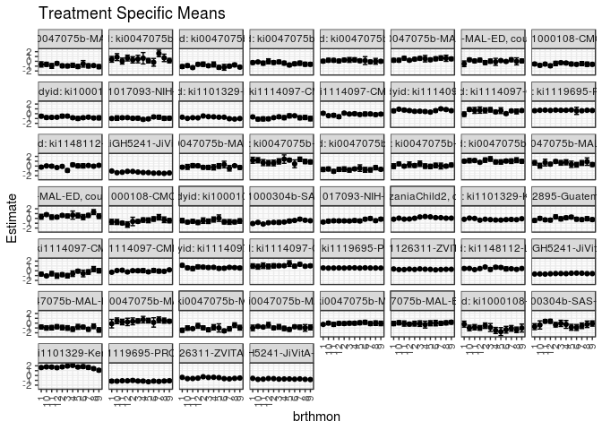

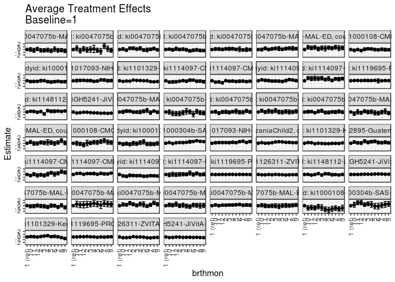

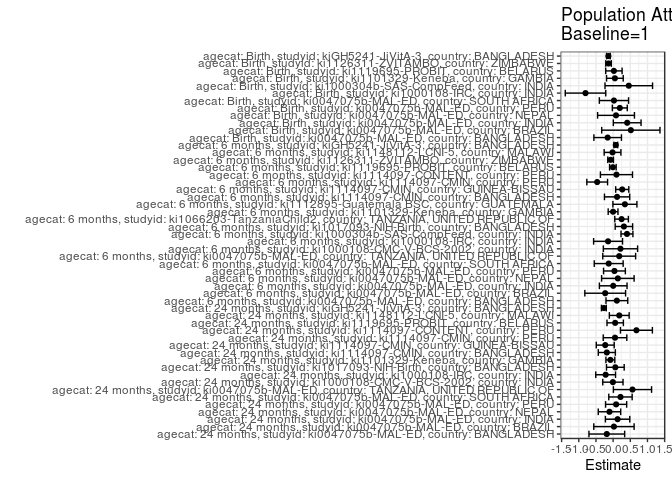

## Results Table

### Parameter: TSM

| agecat | studyid | country | intervention_level | baseline_level | estimate | ci_lower | ci_upper |
| --- | --- | --- | --- | --- | --- | --- | --- |
| Birth | ki0047075b-MAL-ED | BANGLADESH | 1 | NA | -0.8042105 | -1.2156448 | -0.3927762 |
| Birth | ki0047075b-MAL-ED | BANGLADESH | 2 | NA | -0.9204348 | -1.3786843 | -0.4621853 |
| Birth | ki0047075b-MAL-ED | BANGLADESH | 3 | NA | -1.0059091 | -1.4854540 | -0.5263642 |
| Birth | ki0047075b-MAL-ED | BANGLADESH | 4 | NA | -1.2461905 | -1.6981294 | -0.7942516 |
| Birth | ki0047075b-MAL-ED | BANGLADESH | 5 | NA | -0.7740000 | -1.2879349 | -0.2600651 |
| Birth | ki0047075b-MAL-ED | BANGLADESH | 6 | NA | -0.8200000 | -1.1830453 | -0.4569547 |
| Birth | ki0047075b-MAL-ED | BANGLADESH | 7 | NA | -1.2773684 | -1.6638859 | -0.8908510 |
| Birth | ki0047075b-MAL-ED | BANGLADESH | 8 | NA | -0.6569565 | -1.1378929 | -0.1760202 |
| Birth | ki0047075b-MAL-ED | BANGLADESH | 9 | NA | -1.4136842 | -1.8726110 | -0.9547575 |
| Birth | ki0047075b-MAL-ED | BANGLADESH | 10 | NA | -0.9941667 | -1.4388695 | -0.5494639 |
| Birth | ki0047075b-MAL-ED | BANGLADESH | 11 | NA | -0.9460000 | -1.4029497 | -0.4890503 |
| Birth | ki0047075b-MAL-ED | BANGLADESH | 12 | NA | -0.7453846 | -1.1643596 | -0.3264096 |
| Birth | ki0047075b-MAL-ED | BRAZIL | 1 | NA | -0.1120000 | -0.9913394 | 0.7673394 |
| Birth | ki0047075b-MAL-ED | BRAZIL | 2 | NA | 0.3661111 | -0.3430545 | 1.0752768 |
| Birth | ki0047075b-MAL-ED | BRAZIL | 3 | NA | 0.4447059 | -0.0012969 | 0.8907086 |
| Birth | ki0047075b-MAL-ED | BRAZIL | 4 | NA | 0.7188889 | 0.0378265 | 1.3999512 |
| Birth | ki0047075b-MAL-ED | BRAZIL | 5 | NA | 0.5100000 | 0.0243420 | 0.9956580 |
| Birth | ki0047075b-MAL-ED | BRAZIL | 6 | NA | 0.1450000 | -0.8259064 | 1.1159064 |
| Birth | ki0047075b-MAL-ED | BRAZIL | 7 | NA | 0.6868750 | 0.0931168 | 1.2806332 |
| Birth | ki0047075b-MAL-ED | BRAZIL | 8 | NA | 0.5117647 | -0.0240676 | 1.0475970 |
| Birth | ki0047075b-MAL-ED | BRAZIL | 9 | NA | 0.3946429 | 0.0364121 | 0.7528736 |
| Birth | ki0047075b-MAL-ED | BRAZIL | 10 | NA | 0.4794118 | -0.1191032 | 1.0779267 |
| Birth | ki0047075b-MAL-ED | BRAZIL | 11 | NA | 0.2350000 | -0.3373269 | 0.8073269 |
| Birth | ki0047075b-MAL-ED | BRAZIL | 12 | NA | 0.2480000 | -0.5197861 | 1.0157861 |
| Birth | ki0047075b-MAL-ED | INDIA | 1 | NA | -1.4787500 | -1.8919877 | -1.0655123 |
| Birth | ki0047075b-MAL-ED | INDIA | 2 | NA | -0.9737500 | -1.3857743 | -0.5617257 |
| Birth | ki0047075b-MAL-ED | INDIA | 3 | NA | -1.3742857 | -1.7599069 | -0.9886645 |
| Birth | ki0047075b-MAL-ED | INDIA | 4 | NA | -0.8684615 | -1.4245586 | -0.3123644 |
| Birth | ki0047075b-MAL-ED | INDIA | 5 | NA | -0.9942857 | -1.8433430 | -0.1452284 |
| Birth | ki0047075b-MAL-ED | INDIA | 6 | NA | -1.6077778 | -1.9547552 | -1.2608003 |

[output cut: 594 more lines]

### Parameter: E(Y)

| agecat | studyid | country | intervention_level | baseline_level | estimate | ci_lower | ci_upper |
| --- | --- | --- | --- | --- | --- | --- | --- |
| Birth | ki0047075b-MAL-ED | BANGLADESH | NA | NA | -0.9630705 | -1.0989132 | -0.8272278 |
| Birth | ki0047075b-MAL-ED | BRAZIL | NA | NA | 0.4038798 | 0.2296279 | 0.5781316 |
| Birth | ki0047075b-MAL-ED | INDIA | NA | NA | -1.0691133 | -1.2078629 | -0.9303637 |
| Birth | ki0047075b-MAL-ED | NEPAL | NA | NA | -0.9044643 | -1.0439568 | -0.7649718 |
| Birth | ki0047075b-MAL-ED | PERU | NA | NA | -0.0735842 | -0.1836203 | 0.0364518 |
| Birth | ki0047075b-MAL-ED | SOUTH AFRICA | NA | NA | -0.0562791 | -0.2000837 | 0.0875255 |
| Birth | ki1000108-IRC | INDIA | NA | NA | -1.0105831 | -1.1973019 | -0.8238643 |
| Birth | ki1000304b-SAS-CompFeed | INDIA | NA | NA | -0.2697590 | -0.5399211 | 0.0004030 |
| Birth | ki1101329-Keneba | GAMBIA | NA | NA | 1.7036191 | 1.6208471 | 1.7863911 |
| Birth | ki1119695-PROBIT | BELARUS | NA | NA | -1.1463469 | -1.3562674 | -0.9364264 |
| Birth | ki1126311-ZVITAMBO | ZIMBABWE | NA | NA | -0.5151425 | -0.5409938 | -0.4892911 |
| Birth | kiGH5241-JiVitA-3 | BANGLADESH | NA | NA | -0.7240996 | -0.7439385 | -0.7042607 |
| 6 months | ki0047075b-MAL-ED | BANGLADESH | NA | NA | -0.1397960 | -0.2688682 | -0.0107238 |
| 6 months | ki0047075b-MAL-ED | BRAZIL | NA | NA | 0.9717225 | 0.8073791 | 1.1360658 |
| 6 months | ki0047075b-MAL-ED | INDIA | NA | NA | -0.7033969 | -0.8285284 | -0.5782654 |
| 6 months | ki0047075b-MAL-ED | NEPAL | NA | NA | 0.1110452 | -0.0202712 | 0.2423616 |
| 6 months | ki0047075b-MAL-ED | PERU | NA | NA | 1.0543956 | 0.9326967 | 1.1760945 |
| 6 months | ki0047075b-MAL-ED | SOUTH AFRICA | NA | NA | 0.5420735 | 0.3899459 | 0.6942011 |
| 6 months | ki0047075b-MAL-ED | TANZANIA, UNITED REPUBLIC OF | NA | NA | 0.5170513 | 0.3872178 | 0.6468847 |
| 6 months | ki1000108-CMC-V-BCS-2002 | INDIA | NA | NA | -0.5026766 | -0.6536848 | -0.3516685 |
| 6 months | ki1000108-IRC | INDIA | NA | NA | -0.5989297 | -0.7344491 | -0.4634104 |
| 6 months | ki1000304b-SAS-CompFeed | INDIA | NA | NA | -0.6657084 | -0.8024377 | -0.5289791 |
| 6 months | ki1017093-NIH-Birth | BANGLADESH | NA | NA | -0.4389101 | -0.5279432 | -0.3498771 |
| 6 months | ki1066203-TanzaniaChild2 | TANZANIA, UNITED REPUBLIC OF | NA | NA | 0.0809332 | 0.0282644 | 0.1336020 |
| 6 months | ki1101329-Keneba | GAMBIA | NA | NA | -0.1846223 | -0.2354964 | -0.1337483 |
| 6 months | ki1112895-Guatemala BSC | GUATEMALA | NA | NA | -0.0840134 | -0.1945572 | 0.0265305 |
| 6 months | ki1114097-CMIN | BANGLADESH | NA | NA | -0.5780453 | -0.7226627 | -0.4334279 |
| 6 months | ki1114097-CMIN | GUINEA-BISSAU | NA | NA | -0.0418080 | -0.1199942 | 0.0363782 |
| 6 months | ki1114097-CMIN | PERU | NA | NA | 0.6721017 | 0.5829735 | 0.7612299 |
| 6 months | ki1114097-CONTENT | PERU | NA | NA | 1.0684318 | 0.9515274 | 1.1853362 |
| 6 months | ki1119695-PROBIT | BELARUS | NA | NA | 0.5789633 | 0.5190130 | 0.6389137 |
| 6 months | ki1126311-ZVITAMBO | ZIMBABWE | NA | NA | 0.3047138 | 0.2786437 | 0.3307839 |
| 6 months | ki1148112-LCNI-5 | MALAWI | NA | NA | 0.4499285 | 0.3788279 | 0.5210291 |
| 6 months | kiGH5241-JiVitA-3 | BANGLADESH | NA | NA | -0.5935161 | -0.6130518 | -0.5739805 |
| 24 months | ki0047075b-MAL-ED | BANGLADESH | NA | NA | -0.8208255 | -0.9429246 | -0.6987264 |
| 24 months | ki0047075b-MAL-ED | BRAZIL | NA | NA | 0.4466272 | 0.2416144 | 0.6516401 |
| 24 months | ki0047075b-MAL-ED | INDIA | NA | NA | -0.9522907 | -1.0676596 | -0.8369219 |
| 24 months | ki0047075b-MAL-ED | NEPAL | NA | NA | -0.3764474 | -0.4898516 | -0.2630431 |
| 24 months | ki0047075b-MAL-ED | PERU | NA | NA | 0.1199005 | -0.0000331 | 0.2398341 |
| 24 months | ki0047075b-MAL-ED | SOUTH AFRICA | NA | NA | 0.4267017 | 0.3074751 | 0.5459283 |
| 24 months | ki0047075b-MAL-ED | TANZANIA, UNITED REPUBLIC OF | NA | NA | 0.0500935 | -0.0748234 | 0.1750103 |
| 24 months | ki1000108-CMC-V-BCS-2002 | INDIA | NA | NA | -0.5571505 | -0.6585247 | -0.4557763 |
| 24 months | ki1000108-IRC | INDIA | NA | NA | -0.7458150 | -0.8368180 | -0.6548120 |
| 24 months | ki1017093-NIH-Birth | BANGLADESH | NA | NA | -0.9115790 | -1.0095022 | -0.8136559 |
| 24 months | ki1101329-Keneba | GAMBIA | NA | NA | -0.8099290 | -0.8570608 | -0.7627972 |
| 24 months | ki1114097-CMIN | BANGLADESH | NA | NA | -0.8535391 | -0.9644236 | -0.7426546 |
| 24 months | ki1114097-CMIN | GUINEA-BISSAU | NA | NA | -0.1442438 | -0.2323415 | -0.0561461 |
| 24 months | ki1114097-CMIN | PERU | NA | NA | 0.6477778 | 0.5676685 | 0.7278870 |
| 24 months | ki1114097-CONTENT | PERU | NA | NA | 0.5668293 | 0.4302437 | 0.7034148 |
| 24 months | ki1119695-PROBIT | BELARUS | NA | NA | 0.6863435 | 0.5745700 | 0.7981170 |
| 24 months | ki1148112-LCNI-5 | MALAWI | NA | NA | -0.0478508 | -0.1297321 | 0.0340305 |
| 24 months | kiGH5241-JiVitA-3 | BANGLADESH | NA | NA | -1.2978031 | -1.3210763 | -1.2745298 |

### Parameter: ATE

| agecat | studyid | country | intervention_level | baseline_level | estimate | ci_lower | ci_upper |
| --- | --- | --- | --- | --- | --- | --- | --- |
| Birth | ki0047075b-MAL-ED | BANGLADESH | 1 | 1 | 0.0000000 | 0.0000000 | 0.0000000 |
| Birth | ki0047075b-MAL-ED | BANGLADESH | 2 | 1 | -0.1162243 | -0.7320739 | 0.4996254 |
| Birth | ki0047075b-MAL-ED | BANGLADESH | 3 | 1 | -0.2016986 | -0.8335542 | 0.4301571 |
| Birth | ki0047075b-MAL-ED | BANGLADESH | 4 | 1 | -0.4419799 | -1.0531485 | 0.1691886 |
| Birth | ki0047075b-MAL-ED | BANGLADESH | 5 | 1 | 0.0302105 | -0.6281262 | 0.6885473 |
| Birth | ki0047075b-MAL-ED | BANGLADESH | 6 | 1 | -0.0157895 | -0.5644971 | 0.5329182 |
| Birth | ki0047075b-MAL-ED | BANGLADESH | 7 | 1 | -0.4731579 | -1.0376700 | 0.0913542 |
| Birth | ki0047075b-MAL-ED | BANGLADESH | 8 | 1 | 0.1472540 | -0.4856583 | 0.7801663 |
| Birth | ki0047075b-MAL-ED | BANGLADESH | 9 | 1 | -0.6094737 | -1.2258274 | 0.0068801 |
| Birth | ki0047075b-MAL-ED | BANGLADESH | 10 | 1 | -0.1899561 | -0.7957934 | 0.4158811 |
| Birth | ki0047075b-MAL-ED | BANGLADESH | 11 | 1 | -0.1417895 | -0.7566726 | 0.4730936 |
| Birth | ki0047075b-MAL-ED | BANGLADESH | 12 | 1 | 0.0588259 | -0.5283863 | 0.6460382 |
| Birth | ki0047075b-MAL-ED | BRAZIL | 1 | 1 | 0.0000000 | 0.0000000 | 0.0000000 |
| Birth | ki0047075b-MAL-ED | BRAZIL | 2 | 1 | 0.4781111 | -0.6515586 | 1.6077808 |
| Birth | ki0047075b-MAL-ED | BRAZIL | 3 | 1 | 0.5567059 | -0.4292739 | 1.5426857 |
| Birth | ki0047075b-MAL-ED | BRAZIL | 4 | 1 | 0.8308889 | -0.2813538 | 1.9431315 |
| Birth | ki0047075b-MAL-ED | BRAZIL | 5 | 1 | 0.6220000 | -0.3825404 | 1.6265404 |
| Birth | ki0047075b-MAL-ED | BRAZIL | 6 | 1 | 0.2570000 | -1.0529225 | 1.5669225 |
| Birth | ki0047075b-MAL-ED | BRAZIL | 7 | 1 | 0.7988750 | -0.2621559 | 1.8599059 |
| Birth | ki0047075b-MAL-ED | BRAZIL | 8 | 1 | 0.6237647 | -0.4059702 | 1.6534996 |
| Birth | ki0047075b-MAL-ED | BRAZIL | 9 | 1 | 0.5066429 | -0.4428660 | 1.4561517 |
| Birth | ki0047075b-MAL-ED | BRAZIL | 10 | 1 | 0.5914118 | -0.4722883 | 1.6551119 |
| Birth | ki0047075b-MAL-ED | BRAZIL | 11 | 1 | 0.3470000 | -0.7021882 | 1.3961882 |
| Birth | ki0047075b-MAL-ED | BRAZIL | 12 | 1 | 0.3600000 | -0.8073617 | 1.5273617 |
| Birth | ki0047075b-MAL-ED | INDIA | 1 | 1 | 0.0000000 | 0.0000000 | 0.0000000 |
| Birth | ki0047075b-MAL-ED | INDIA | 2 | 1 | 0.5050000 | -0.0785490 | 1.0885490 |
| Birth | ki0047075b-MAL-ED | INDIA | 3 | 1 | 0.1044643 | -0.4607517 | 0.6696803 |
| Birth | ki0047075b-MAL-ED | INDIA | 4 | 1 | 0.6102885 | -0.0825386 | 1.3031155 |
| Birth | ki0047075b-MAL-ED | INDIA | 5 | 1 | 0.4844643 | -0.4598152 | 1.4287437 |
| Birth | ki0047075b-MAL-ED | INDIA | 6 | 1 | -0.1290278 | -0.6686190 | 0.4105635 |

[output cut: 594 more lines]

### Parameter: PAR

| agecat | studyid | country | intervention_level | baseline_level | estimate | ci_lower | ci_upper |
| --- | --- | --- | --- | --- | --- | --- | --- |
| Birth | ki0047075b-MAL-ED | BANGLADESH | 1 | NA | -0.1588600 | -0.5601582 | 0.2424382 |
| Birth | ki0047075b-MAL-ED | BRAZIL | 1 | NA | 0.5158798 | -0.3321147 | 1.3638742 |
| Birth | ki0047075b-MAL-ED | INDIA | 1 | NA | 0.4096367 | 0.0057826 | 0.8134908 |
| Birth | ki0047075b-MAL-ED | NEPAL | 1 | NA | 0.0842857 | -0.4522835 | 0.6208549 |
| Birth | ki0047075b-MAL-ED | PERU | 1 | NA | 0.1945239 | -0.0229511 | 0.4119989 |
| Birth | ki0047075b-MAL-ED | SOUTH AFRICA | 1 | NA | 0.0240913 | -0.4013286 | 0.4495112 |
| Birth | ki1000108-IRC | INDIA | 1 | NA | -0.8041315 | -1.3935851 | -0.2146779 |
| Birth | ki1000304b-SAS-CompFeed | INDIA | 1 | NA | 0.4560743 | -0.2360876 | 1.1482362 |
| Birth | ki1101329-Keneba | GAMBIA | 1 | NA | 0.0513274 | -0.1918019 | 0.2944568 |
| Birth | ki1119695-PROBIT | BELARUS | 1 | NA | 0.0226677 | -0.2158709 | 0.2612063 |
| Birth | ki1126311-ZVITAMBO | ZIMBABWE | 1 | NA | -0.1337232 | -0.2143037 | -0.0531426 |
| Birth | kiGH5241-JiVitA-3 | BANGLADESH | 1 | NA | -0.1371982 | -0.1912386 | -0.0831579 |
| 6 months | ki0047075b-MAL-ED | BANGLADESH | 1 | NA | 0.1090003 | -0.2078351 | 0.4258357 |
| 6 months | ki0047075b-MAL-ED | BRAZIL | 1 | NA | -0.2303886 | -0.8234425 | 0.3626652 |
| 6 months | ki0047075b-MAL-ED | INDIA | 1 | NA | 0.0026557 | -0.3998881 | 0.4051996 |
| 6 months | ki0047075b-MAL-ED | NEPAL | 1 | NA | 0.1374619 | -0.3358253 | 0.6107491 |
| 6 months | ki0047075b-MAL-ED | PERU | 1 | NA | 0.0385184 | -0.2789801 | 0.3560169 |
| 6 months | ki0047075b-MAL-ED | SOUTH AFRICA | 1 | NA | -0.1288476 | -0.5497161 | 0.2920210 |
| 6 months | ki0047075b-MAL-ED | TANZANIA, UNITED REPUBLIC OF | 1 | NA | 0.1768013 | -0.3015072 | 0.6551097 |
| 6 months | ki1000108-CMC-V-BCS-2002 | INDIA | 1 | NA | 0.2137449 | -0.2855054 | 0.7129953 |
| 6 months | ki1000108-IRC | INDIA | 1 | NA | -0.1470876 | -0.5682331 | 0.2740578 |
| 6 months | ki1000304b-SAS-CompFeed | INDIA | 1 | NA | 0.4029123 | 0.2298669 | 0.5759577 |
| 6 months | ki1017093-NIH-Birth | BANGLADESH | 1 | NA | 0.3139745 | 0.0601068 | 0.5678421 |
| 6 months | ki1066203-TanzaniaChild2 | TANZANIA, UNITED REPUBLIC OF | 1 | NA | 0.2463440 | 0.0484046 | 0.4442833 |
| 6 months | ki1101329-Keneba | GAMBIA | 1 | NA | -0.0015715 | -0.1439413 | 0.1407983 |
| 6 months | ki1112895-Guatemala BSC | GUATEMALA | 1 | NA | 0.3428914 | -0.0067083 | 0.6924911 |
| 6 months | ki1114097-CMIN | BANGLADESH | 1 | NA | 0.1152240 | -0.2521263 | 0.4825742 |
| 6 months | ki1114097-CMIN | GUINEA-BISSAU | 1 | NA | 0.2653162 | 0.0743090 | 0.4563234 |
| 6 months | ki1114097-CMIN | PERU | 1 | NA | -0.4640491 | -0.7659713 | -0.1621269 |
| 6 months | ki1114097-CONTENT | PERU | 1 | NA | 0.0970318 | -0.3701267 | 0.5641902 |
| 6 months | ki1119695-PROBIT | BELARUS | 1 | NA | -0.0073957 | -0.1030348 | 0.0882435 |
| 6 months | ki1126311-ZVITAMBO | ZIMBABWE | 1 | NA | -0.0730696 | -0.1556902 | 0.0095511 |
| 6 months | ki1148112-LCNI-5 | MALAWI | 1 | NA | -0.0171303 | -0.2611553 | 0.2268946 |
| 6 months | kiGH5241-JiVitA-3 | BANGLADESH | 1 | NA | 0.0772737 | 0.0226108 | 0.1319366 |
| 24 months | ki0047075b-MAL-ED | BANGLADESH | 1 | NA | -0.1840398 | -0.7037635 | 0.3356840 |
| 24 months | ki0047075b-MAL-ED | BRAZIL | 1 | NA | 0.0236272 | -0.5637401 | 0.6109945 |
| 24 months | ki0047075b-MAL-ED | INDIA | 1 | NA | 0.1300777 | -0.2248185 | 0.4849738 |
| 24 months | ki0047075b-MAL-ED | NEPAL | 1 | NA | -0.1064474 | -0.4330311 | 0.2201364 |
| 24 months | ki0047075b-MAL-ED | PERU | 1 | NA | 0.0874005 | -0.2196371 | 0.3944381 |
| 24 months | ki0047075b-MAL-ED | SOUTH AFRICA | 1 | NA | 0.2139076 | -0.1260633 | 0.5538784 |
| 24 months | ki0047075b-MAL-ED | TANZANIA, UNITED REPUBLIC OF | 1 | NA | 0.5637601 | 0.0078268 | 1.1196935 |
| 24 months | ki1000108-CMC-V-BCS-2002 | INDIA | 1 | NA | -0.0068564 | -0.3021094 | 0.2883966 |
| 24 months | ki1000108-IRC | INDIA | 1 | NA | -0.2177010 | -0.5057191 | 0.0703172 |
| 24 months | ki1017093-NIH-Birth | BANGLADESH | 1 | NA | 0.0646613 | -0.1928321 | 0.3221546 |
| 24 months | ki1101329-Keneba | GAMBIA | 1 | NA | -0.0802847 | -0.2097834 | 0.0492139 |
| 24 months | ki1114097-CMIN | BANGLADESH | 1 | NA | -0.1835391 | -0.4320527 | 0.0649745 |
| 24 months | ki1114097-CMIN | GUINEA-BISSAU | 1 | NA | -0.2294521 | -0.4907509 | 0.0318467 |
| 24 months | ki1114097-CMIN | PERU | 1 | NA | 0.0550855 | -0.2884345 | 0.3986054 |
| 24 months | ki1114097-CONTENT | PERU | 1 | NA | 0.6782578 | 0.2132295 | 1.1432862 |
| 24 months | ki1119695-PROBIT | BELARUS | 1 | NA | 0.0599725 | -0.1788781 | 0.2988232 |
| 24 months | ki1148112-LCNI-5 | MALAWI | 1 | NA | 0.1785595 | -0.1098191 | 0.4669380 |
| 24 months | kiGH5241-JiVitA-3 | BANGLADESH | 1 | NA | -0.2694873 | -0.3400068 | -0.1989678 |